# Reproducible Research Peer Assignment #1

## Loading and preprocessing the data

Activity.csv data will be read into R using read.csv

```r
activity<-read.csv('/Users/Cherry/Downloads/activity.csv')
```

Take a peak at the data using dplyr

```r
library(dplyr)
activity<-tbl_df(activity)
str(activity)
```

```
## Classes 'tbl_df', 'tbl' and 'data.frame':    17568 obs. of  3 variables:
##  $ steps   : int  NA NA NA NA NA NA NA NA NA NA ...
##  $ date    : Factor w/ 61 levels "2012-10-01","2012-10-02",..: 1 1 1 1 1 1 1 1 1 1 ...
##  $ interval: int  0 5 10 15 20 25 30 35 40 45 ...
```

Date is currently a factor and will change it date class

```r
activity$datec<-as.character(activity$date)
activity$dated<-as.Date(activity$datec)
```

## What is mean total number of steps taken per day?

First, generate a histogram of total number of steps taken each day

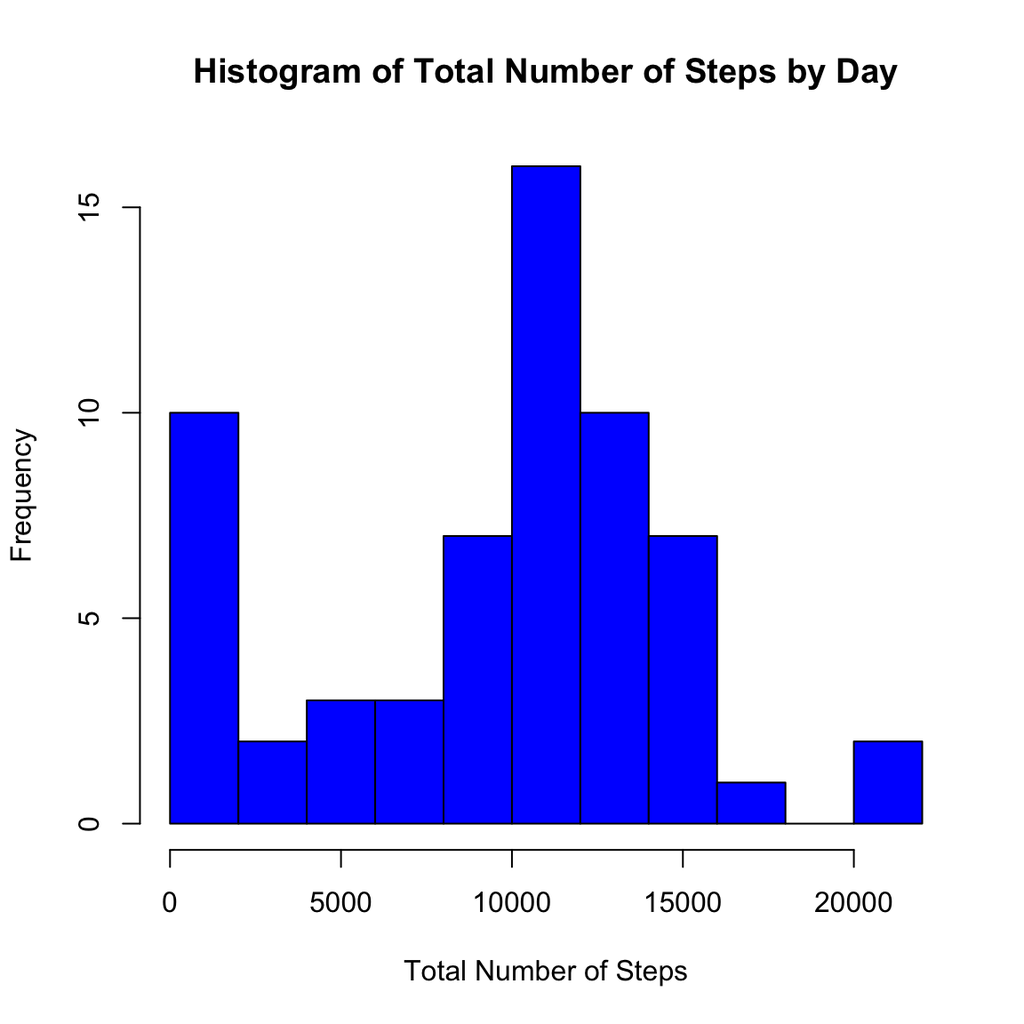

```r
activity1<-
  activity %>%
  group_by(date) %>%
  summarize(totsteps=sum(steps, na.rm=TRUE))

hist(activity1$totsteps, main='Histogram of Total Number of Steps by Day', xlab='Total Number of Steps', ylab='Frequency', col='blue', breaks=10)
```

Find the mean and median of total number of steps taken per day

```r
mean(activity1$totsteps, na.rm=TRUE)
```

```
## [1] 9354.23
```

```r
median(activity1$totsteps, na.rm=TRUE)
```

```
## [1] 10395
```

## What is the average daily activity pattern?

Via figure, explore the pattern of average steps taken across days over 5-minute intervals

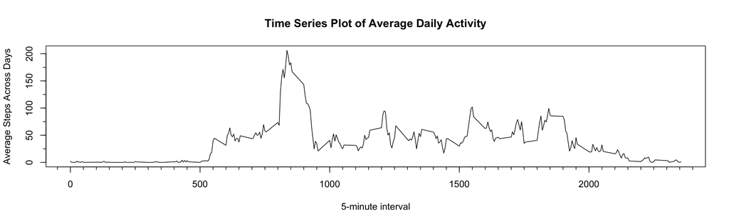

```r
activity1<-
  activity %>%
  group_by(interval) %>%
  summarise(avgsteps=mean(steps, na.rm=TRUE))

with(activity1, plot(interval, avgsteps, main='Time Series Plot of Average Daily Activity', xlab='5-minute interval', ylab='Average Steps Across Days', type='l'))
library(Hmisc)
minor.tick(nx=10)
```

Based on the figure, the highest average steps is around 850. Let’s find out exactly when.

```r
filter(activity1, avgsteps==max(avgsteps))
```

```
## Source: local data frame [1 x 2]
##
##   interval avgsteps
## 1      835 206.1698
```

## Imputing missing values

Obtain the number of missings in each variable

```r
sum(is.na(activity$date))
```

```
## [1] 0
```

```r
sum(is.na(activity$steps))
```

```
## [1] 2304
```

```r
sum(is.na(activity$interval))
```

```
## [1] 0
```

There are 2304 observations with missing steps, will replace them with mean of steps, save them in new dataset called activity.imp.

```r
activity.imp<-activity
activity.imp$steps[is.na(activity.imp$steps)]<-mean(activity.imp$steps, na.rm=TRUE)
sum(is.na(activity.imp$steps))
```

```
## [1] 0
```

Regenrate histogram of total number of steps take each day, and calculate mean and median total number of steps taken per day.

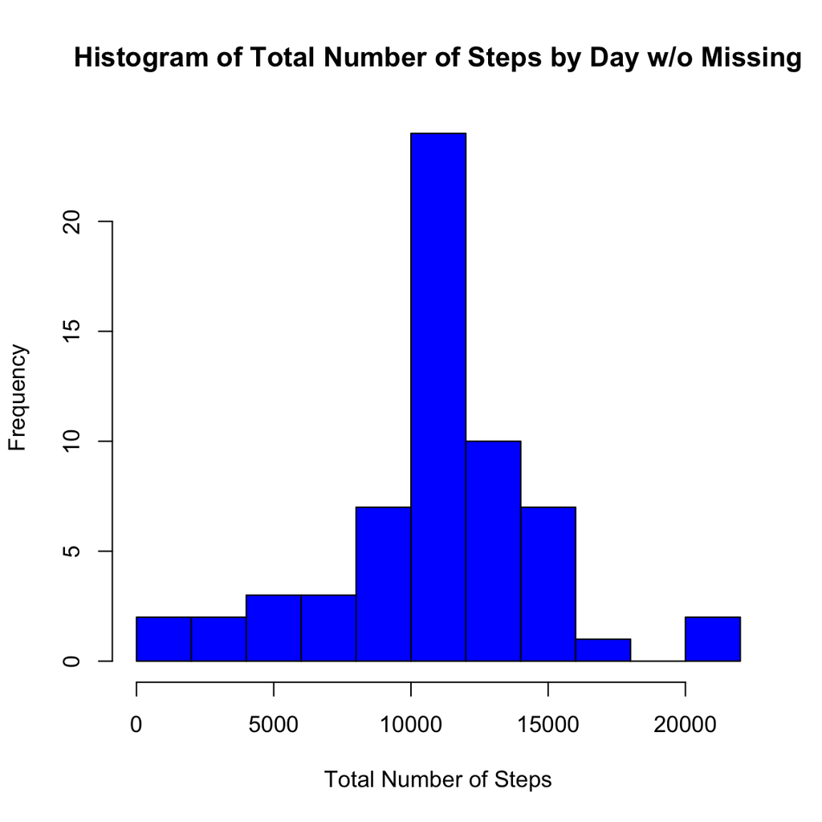

```r
activity.imp1<-
  activity.imp %>%
  group_by(date) %>%
  summarise(totsteps=sum(steps, na.rm=TRUE))

hist(activity.imp1$totsteps, main='Histogram of Total Number of Steps by Day w/o Missing', xlab='Total Number of Steps', ylab='Frequency', col='blue', breaks=10)
```

```r
mean(activity.imp1$totsteps, na.rm=TRUE)
```

```
## [1] 10766.19
```

```r
median(activity.imp1$totsteps, na.rm=TRUE)
```

```
## [1] 10766.19
```

Mean and median of total number of steps taken in a day are different now after imputation.

## Are there differences in activity patterns between weekday and weekends?

Create variables for day of the week (day), and whether it’s a weekday (weekday)

```r
activity.imp$day<-weekdays(activity$dated)
activity.imp$weekday<-ifelse(activity.imp$day %in% c('Monday', 'Tuesday', 'Wednesday', 'Thursday', 'Friday'), 'Weekday', 'Weekend')
activity.imp$weekday<-as.factor(activity.imp$weekday)
```

A panel plot containing a time series plot of the 5-minute interval (x-axis) and the average number of steps taken, averaged across all weekday days or weekend days (y-axis)

First, create a summary dataset of average number of steps taken by weekday and interval uding dplyr.

```r
activity.imp1<-
  activity.imp %>%
  group_by(weekday, interval) %>%
  summarise(avgsteps=mean(steps))
```

Then apply ggplot2 to generate panel plot.

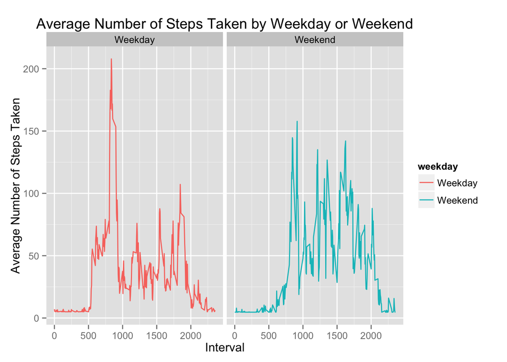

```r
library(ggplot2)
ggplot(activity.imp1, aes(x=interval, y=avgsteps, colour=weekday)) +
  geom_line() +
  xlab("Interval") +
  ylab("Average Number of Steps Taken") +
  ggtitle("Average Number of Steps Taken by Weekday or Weekend") +
  facet_wrap(~weekday)
```